# Default R Graphs

Cevi Herdian, B. Sc

18.12.2018

**Note:**

-An R Notebook is an R Markdown document with chunks that can be executed independently and interactively, with output visible immediately beneath the input.

-Notebook output are available as HTML, PDF, Word, or Latex.

-This Notebook as HTML is preferably open with Google Chrome.

-R-Code can be extracted as Rmd file under the button “Code” in the notebook.

-This Notebook using iterative development. It means the process starts with a simple implementation of a small set of idea requirements and iteratively enhances the evolving versions until the complete version is implemented and perfect.

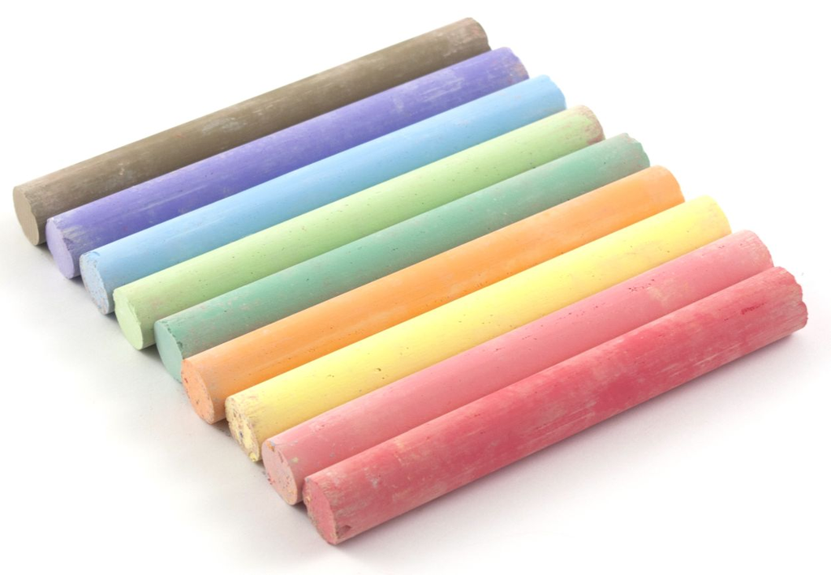

```r
#quelle:https://www.waltersandwalters.co.uk/WSC-CSC-School-Black-and-Chalk-Board-Chalk-Sticks
```

# Introduction and welcome

**Why R?:**

- Free and open source
- Built for statistical computing
- Visualization tools
- Tools for building Models

**Learning Objectives:**

- How to create beautiful, useful, and insightful graphics and charts
- How to customize the look of them

> All languages have their inconsistencies include R Programming. This documentation helps us to create visualizing in default R graphics before to far away using the packages.

# 1-Creating and Saving Graphs in R

**Creating graphs:**

Used `mtcars` dataset for this section:

```r
?mtcars
head(mtcars,5)
```

|  | mpg | cyl | disp | hp | drat | wt | qsec | vs | am | gear | carb |
| --- | --- | --- | --- | --- | --- | --- | --- | --- | --- | --- | --- |
| Mazda RX4 | 21.0 | 6 | 160 | 110 | 3.90 | 2.620 | 16.46 | 0 | 1 | 4 | 4 |
| Mazda RX4 Wag | 21.0 | 6 | 160 | 110 | 3.90 | 2.875 | 17.02 | 0 | 1 | 4 | 4 |
| Datsun 710 | 22.8 | 4 | 108 | 93 | 3.85 | 2.320 | 18.61 | 1 | 1 | 4 | 1 |
| Hornet 4 Drive | 21.4 | 6 | 258 | 110 | 3.08 | 3.215 | 19.44 | 1 | 0 | 3 | 1 |
| Hornet Sportabout | 18.7 | 8 | 360 | 175 | 3.15 | 3.440 | 17.02 | 0 | 0 | 3 | 2 |

Created a graphs with `plot()` function:

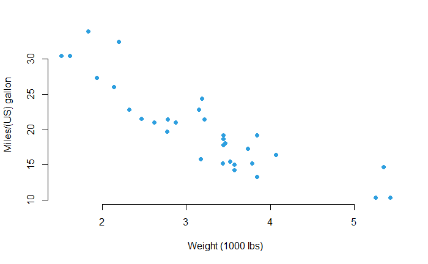

```r
plot(x = mtcars$wt, y = mtcars$mpg,
     pch = 16, frame = FALSE,
     xlab = "Weight (1000 lbs)", ylab = "Miles/(US) gallon", col = "#2E9FDF")
```

**Saving graphs:**

There are two ways of saving graphs in R

1. In RStudio IDE:

Plots panel -> Export -> Save as Image or Save as PDF

[figure not shown]

```r
#preference:http://www.sthda.com/english/wiki/r-base-graphs
```

2. Using R codes:
- Choose the format
- Create the graphs
- Enter the dev.off() command

Example->

**Note:** The file you save are in the current working directory.

The command to get directory is `getwd()`

```r
# 1. Choose the format
png("rplot.jpg") #width = 25, height = "25"
# 2. Create the graphs
plot(x = mtcars$wt, y = mtcars$mpg,
     pch = 16, frame = FALSE,
     xlab = "wt", ylab = "mpg", col = "#2E9FDF")
# 3. Save the file with dev.off() command in directory
dev.off()
```

File formats for exporting plots are:

- pdf(“rplot.pdf”): pdf file
- png(“rplot.png”): png file
- jpeg(“rplot.jpg”): jpeg file
- postscript(“rplot.ps”): postscript file
- bmp(“rplot.bmp”): bmp file
- win.metafile(“rplot.wmf”): windows metafile

# 2-Standard graphical formatting

## 2.1 Introduction `plot()` function

`plot()` function is generic function for plotting of R objects in basic graphs.

- `plot()` : the main function.
- `par()` : the default settings (rows x columns) for plots.
- There are many other plot functions which are specific to some tasks such as `hist()`, `boxplot()`, etc. Most of them take the same arguments as the `plot()` function.

Formula:

> plot(x, y, type=“p”)
- **x** and **y**: the coordinates of points to plot
- `type`:
  - “p” for points,
  - “l” for lines,
  - “b” for both,
  - “c” for the lines part alone of “b”,
  - “o” for both ‘overplotted’,
  - “h” for ‘histogram’ like (or ‘high-density’) vertical lines,
  - “s” for stair steps,
  - “S” for other steps, see ‘Details’ below,
  - “n” for no plotting.

Example:

```r
par(mfrow=c(3,3), mar=c(3,3,1,0)+.5, mgp=c(1.6,.6,0))  # set up the graphics
x<-1:5; y=x*x
plot(x, y, type="p",col="blue")
plot(x, y, type="l",col="bisque")
```

```r
plot(x,y, type="b",col="green")
plot(x, y, type="c",col="red")
```

```r
plot(x, y, type="o",col="pink")
plot(x,y, type="h",col="orange")
```

```r
plot(x, y, type="s",col="purple")
plot(x, y, type="S",col="black")
```

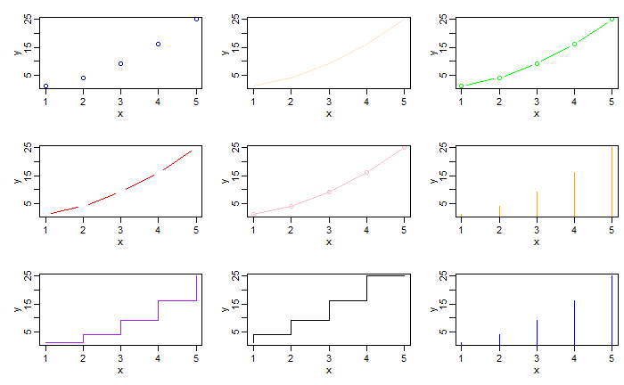

```r
plot(x,y, type="h",col="blue")
```

```r
#for more color type used the sintaks color()
```

More info about `plot()` go to RDocumentation [here](https://www.rdocumentation.org/packages/graphics/versions/3.5.1/topics/plot)

## 2.2 Titles

- `main="test"`: main titles
- `sub="text"`: subtitle
- `xlab="test"`: the name of the x axis
- `ylab="test"`: the name of the y axis.

**Main title and axis labels:**

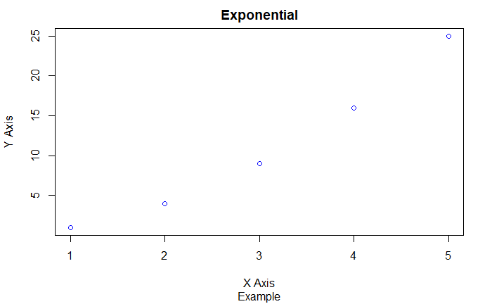

```r
x<-1:5; y=x*x
plot(x, y, type="p",col="blue",main="Exponential",sub="Example",ylab="Y Axis",xlab="X Axis")
```

**Title colors:**

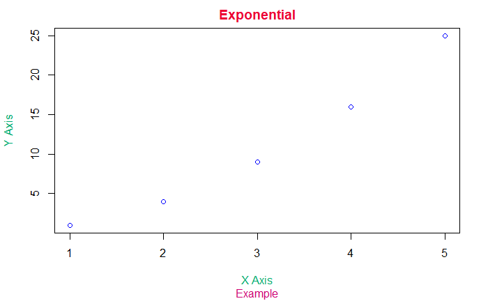

```r
x<-1:5; y=x*x
plot(x, y, type="p",col="blue",main="Exponential",sub="Example",ylab="Y Axis",xlab="X Axis",
     col.main="#EC0033", col.lab="#00AB6F", col.sub="#CD0074")
```

**The font style:**

The possible values for the font style are :

1: normal text

2: bold

3: italic

4: bold and italic

5 : Symbol font

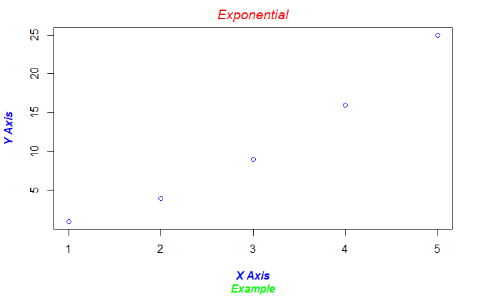

```r
x<-1:5; y=x*x
plot(x, y, type="p",col="blue",main="Exponential",sub="Example",ylab="Y Axis",xlab="X Axis",
     col.main="red", col.lab="blue", col.sub="green",
     font.main=3, font.lab=4, font.sub=4
     )
```

**The font size:**

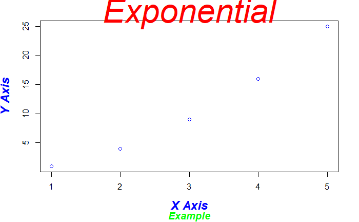

```r
x<-1:5; y=x*x
plot(x, y, type="p",col="blue",main="Exponential",sub="Example",ylab="Y Axis",xlab="X Axis",
     col.main="red", col.lab="blue", col.sub="green",
     font.main=3, font.lab=4, font.sub=4,
     cex.main=4, cex.lab=1.5, cex.sub=1.2
     )
```

**Use the title() function:**

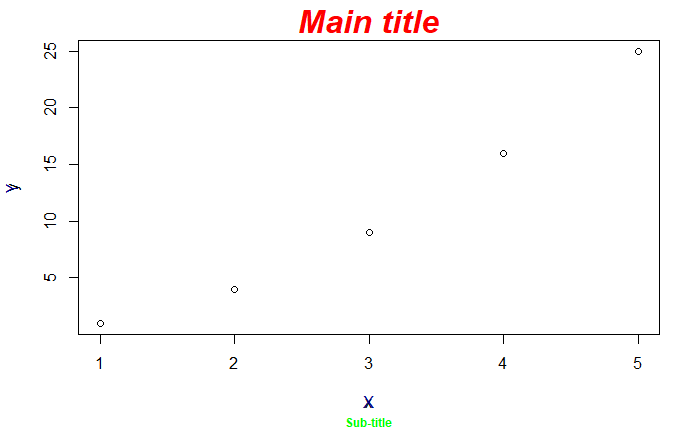

```r
x<-1:5; y=x*x
plot(x, y, type="p")
title(main = "Main title", sub = "Sub-title",
      xlab = "X", ylab = "Y",
      cex.main = 2,   font.main= 4, col.main= "red",
      cex.sub = 0.75, font.sub = 2, col.sub = "green",
      col.lab ="darkblue"
      )
```

**Customize the titles using par() function:**

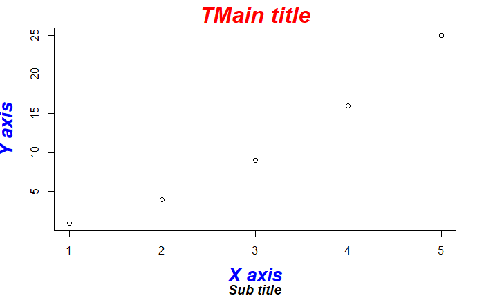

```r
par(
  # Change the colors
  col.main="red", col.lab="blue", col.sub="black",
  # Titles in italic and bold
  font.main=4, font.lab=4, font.sub=4,
  # Change font size
  cex.main=2, cex.lab=1.7, cex.sub=1.2
  )
plot(x, y, type="p",
     main="TMain title",
        xlab="X axis",
        ylab="Y axis",
        sub="Sub title"
     )
```

## 2.2 Legend

- `legend()`: the position can be “bottomleft”, “bottomright”, “topleft”, “topright” or exact coordinates.

**R legend function:**

Formula:

> legend(x, y=NULL, legend, fill, col, bg)

Example:

```r
# Generate example data
x<-1:5; y1=x*x; y2=3*y1
plot(x, y1, type="b", pch=19, col="#FFD900", xlab="x", ylab="y")
# Add a line
lines(x, y2, pch=18, col="#8C6DD7", type="b", lty=2)
```

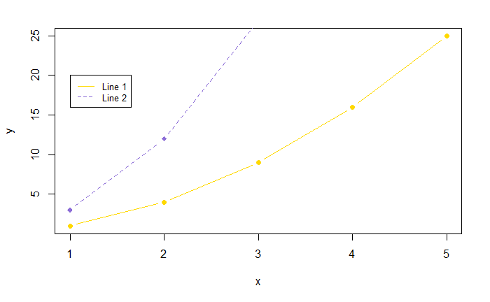

```r
# Add a legend
legend(1, 20, legend=c("Line 1", "Line 2"),
       col=c("#FFD900", "#8C6DD7"), lty=1:2, cex=0.8)
```

Create R function to avoid repeating graphs code:

```r
# Generate example data
make_plot<-function(){
x<-1:5; y1=x*x; y2=3*y1
plot(x, y1, type="b", pch=19, col="red", xlab="x", ylab="y")
# Add a line
lines(x, y2, pch=18, col="blue", type="b", lty=2)
# Add a legend
legend(1, 20, legend=c("Line 1", "Line 2"),
       col=c("red", "blue"), lty=1:2, cex=0.8)
}
```

**Title, text font and background color of the legend box:**

- title: The title of the legend
- text.font: an integer specifying the font style of the legend text; possible values are :
  - 1: normal
  - 2: bold
  - 3: italic
  - 4: bold and italic
  - bg: background color of the legend box

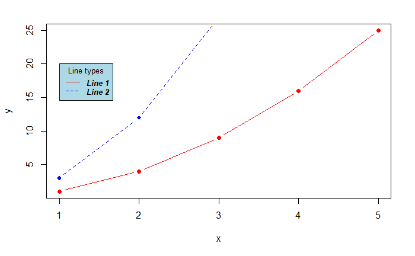

```r
make_plot()
# Add a legend to the plot
legend(1,20, legend=c("Line 1", "Line 2"),
       col=c("red", "blue"), lty=1:2, cex=0.8,
       title="Line types", text.font=4, bg="lightblue")
```

**Border of the legend box:**

- box.lty: modify the line type
- box.lwd: modify the width
- box.col: modify the color

```r
par(mfrow=c(2,1), mar=c(3,3,1,0)+.5, mgp=c(1.6,.6,0))  # set up the graphics
# Remove legend border using box.lty = 0
make_plot()
legend(1,20, legend=c("Line 1", "Line 2"),
       col=c("red", "blue"), lty=1:2, cex=0.8,
       box.lty=0)
```

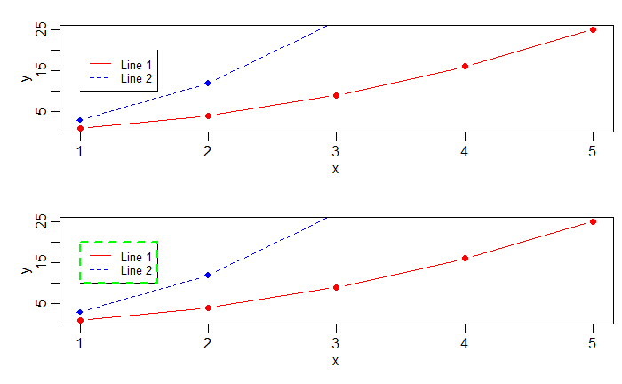

```r
# Change the border
make_plot()
legend(1,20, legend=c("Line 1", "Line 2"),
       col=c("red", "blue"), lty=1:2, cex=0.8,
       box.lty=2, box.lwd=2, box.col="green")
```

**The legend position by keywords:**

Using the following keywords : “bottomright”, “bottom”, “bottomleft”, “left”, “topleft”, “top”, “topright”, “right” and “center”.

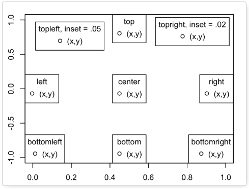

```r
par(mfrow=c(2,1), mar=c(3,3,1,0)+.5, mgp=c(1.6,.6,0))  # set up the graphics
# Remove legend border using box.lty = 0
make_plot()
legend("center", legend=c("Line 1", "Line 2"),
       col=c("red", "blue"),box.lty=0)
```

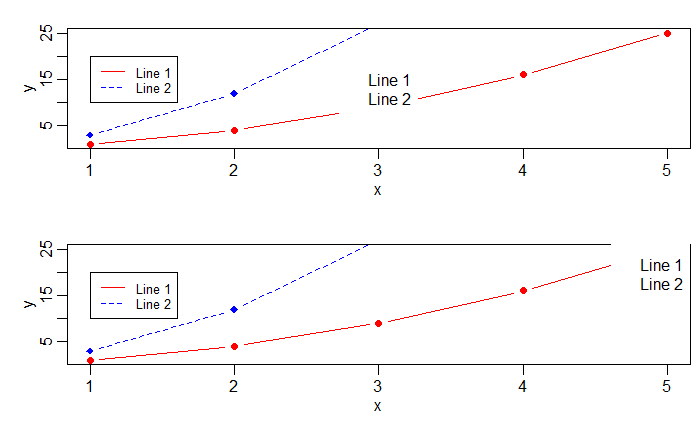

```r
make_plot()
legend("topright", legend=c("Line 1", "Line 2"),
       col=c("red", "blue"),
       box.lty=0)
```

## 2.3 Text

`text()` and `mtext()` R functions can be used To add a text to a plot.

**Texts within the graph:**

Formula:

> text(x, y, labels)

Example:

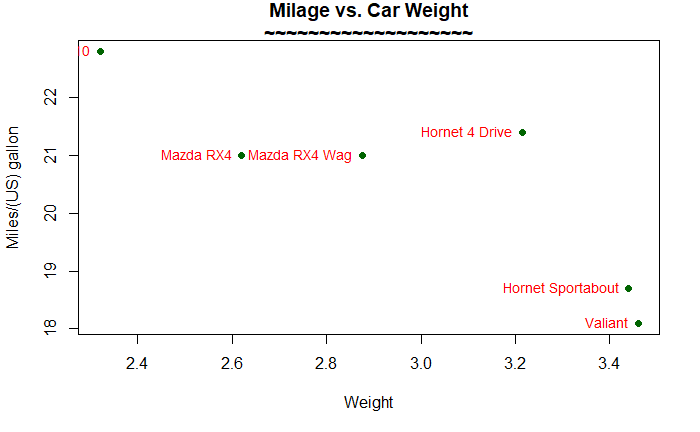

```r
d<-head(mtcars)
plot(d[,'wt'], d[,'mpg'],
     main="Milage vs. Car Weight\n~~~~~~~~~~~~~~~~~~~",
      xlab="Weight", ylab="Miles/(US) gallon",
      pch=19, col="darkgreen")
text(d[,'wt'], d[,'mpg'],  row.names(d),
     cex=0.85, pos=2,col="red")
```

**Text in the margins of the graph:**

- text : the text to be written
- side : an integer specifying the side of the plot; Possible values are :
- 1: bottom
- 2: left
- 3: top
- 4: right

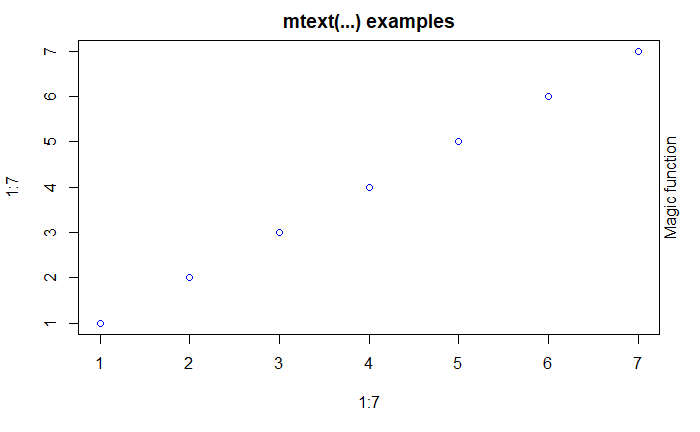

```r
plot(1:7, 1:7,
     main="mtext(...) examples",col="blue")
mtext("Magic function", side=4)
```

**Mathematical annotation within the graph:**

Example:

```r
plot(1:7, 1:7,
     main="text(...) examples",col="black")
text(2, 4, expression(hat(beta) == (X^t * X)^{-1} * X^t * y))
```

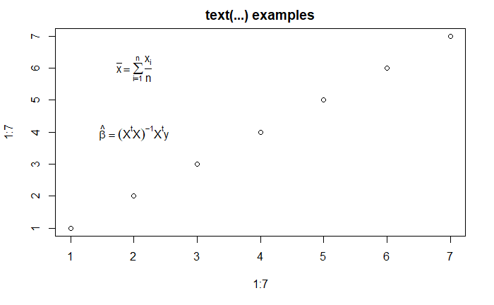

```r
text(2, 6, expression(bar(x) == sum(frac(x[i], n), i==1, n)))
```

## 2.4 Types

An option for plot types can be:

`type`: * “p” for points,

```
  * "l" for lines,

  * "b" for both,

  * "c" for the lines part alone of "b",

  * "o" for both 'overplotted',

  * "h" for 'histogram' like (or 'high-density') vertical lines,

  * "s" for stair steps,

  * "S" for other steps, see 'Details' below,

  * "n" for no plotting.
```

```r
x <- rnorm(100)
par(mfrow = c(2,2))
plot(x, type = "p", main = "points", ylab = "", xlab = "",col="red")
plot(x, type = "o", main = "overplotted", ylab = "", xlab = "",col="green")
```

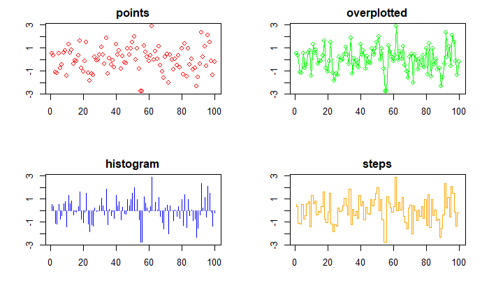

```r
plot(x, type = "h", main = "histogram", ylab = "", xlab = "",col="blue")
plot(x, type = "S", main = "steps", ylab = "", xlab = "",col="orange")
```

## 2.5 Axis

**Add an axis to a plot:**

Formula:

> axis(side, at=NULL, labels=TRUE)

side :

- 1: below
- 2: left
- 3: above
- 4: right
- at: The position
- labels: Texts for tick-mark labels.

Example :

```r
par(mfrow=c(3,1), mar=c(3,3,1,0)+.5, mgp=c(1.6,.6,0))  # set up the graphics
x<-1:3; y=x*x
# Example 1
plot(x, y, axes = FALSE)
axis(side=1, at = 1:3, labels=LETTERS[1:3])
```

```r
axis(2)
# Example 2
plot(x, y, axes = FALSE)
```

```r
axis(side=1, at=1:3, labels=LETTERS[1:3])
axis(2)
```

```r
box() #- To make it look like "usual" plot
#Example3:
plot(x, y, pch=18, col="red", type="b",
     frame=FALSE, xaxt="n") # Remove x axis
```

```r
axis(1, 1:4, LETTERS[1:4], col.axis="blue")
axis(3, col = "darkgreen", lty = 2, lwd = 0.5)
```

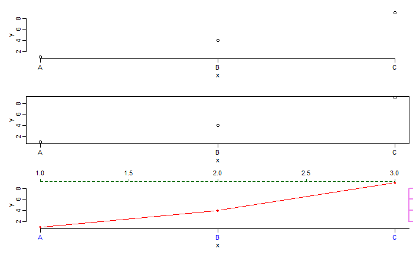

```r
axis(4, col = "violet", col.axis = "dark violet", lwd = 2)
```

**Axis scale:**

- xlim: the limit of x axis; format : xlim = c(min, max)
- ylim: the limit of y axis; format: ylim = c(min, max)

Transformation to log scale:

- log = “x”
- log = “y”
- log = “xy”*

Example:

```r
par(mfrow=c(3,1), mar=c(3,3,1,0)+.5, mgp=c(1.6,.6,0))  # set up the graphics
x<-1:20; y=x*x
# Simple graph
plot(x, y,col="#FF5300")
# Enlarge the scale
plot(x, y, xlim=c(1,15), ylim=c(1,150),col="#FF5300")
```

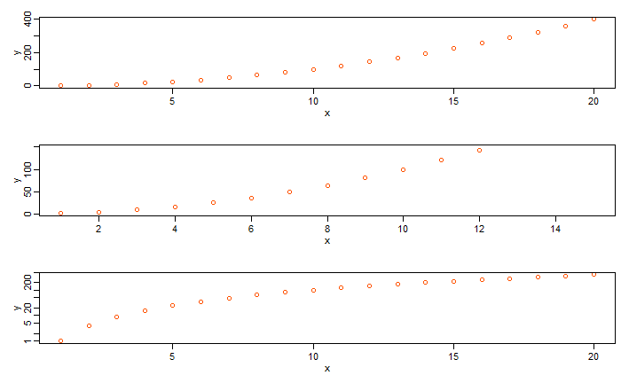

```r
# Log scale
plot(x, y, log="y",col="#FF5300")
```

**Axes fonts:**

Remove them with `axes=FALSE`.

```r
par(mfrow=c(2,1), mar=c(3,3,1,0)+.5, mgp=c(1.6,.6,0))  # set up the graphics
x1<-1:10
x2<-11:20
plot(x1,x2,axes=FALSE)
plot(x1,x2,axes=FALSE)
```

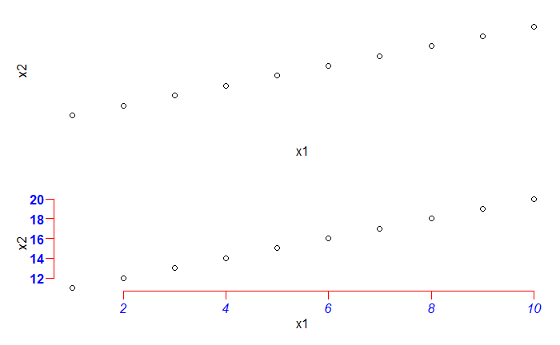

```r
axis(1,col="red",col.axis="blue",font.axis=3)
axis(2,col="red",col.axis="blue",font.axis=2,las=2)
```

**Axes positions:**

Use `las` function to specified the style of axis labels.

- 0 : always parallel to the axis [default]
- 1 : always horizontal
- 2 : always perpendicular to the axis
- 3 : always vertical

```r
x1 <- rnorm(150)
par(mfrow = c(2,2))
plot(x1, las = 0, main = "las = 0", sub = "always parallel to the axis", xlab = "", ylab = "",col="blue")
plot(x1, las = 1, main = "las = 1", sub = "always horizontal", xlab = "", ylab = "",col="blue")
```

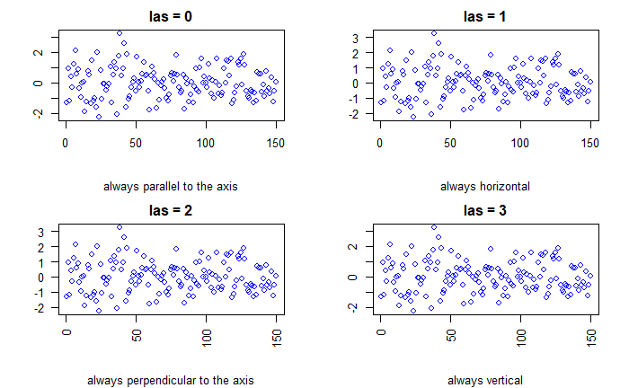

```r
plot(x1, las = 2, main = "las = 2", sub = "always perpendicular to the axis", xlab = "", ylab = "",col="blue")
plot(x1, las = 3, main = "las = 3", sub = "always vertical", xlab = "", ylab = "",col="blue")
```

## 2.6 Margins par()

Formula:

> par(mfrow=c(2,1), mar=c(3,3,1,0)+.5, mgp=c(1.6,.6,0)) # set up the graphics

See `?par` to learn more about the topic.

## 2.7 Colors

Use by name (e.g col = “red”) or as a hexadecimal RGB triplet (such as col = “#FFCC00”).

**Default color in R:**

```r
colors() # list the r colors
```

```
  [1] "white"                "aliceblue"            "antiquewhite"         "antiquewhite1"
  [5] "antiquewhite2"        "antiquewhite3"        "antiquewhite4"        "aquamarine"
  [9] "aquamarine1"          "aquamarine2"          "aquamarine3"          "aquamarine4"
 [13] "azure"                "azure1"               "azure2"               "azure3"
 [17] "azure4"               "beige"                "bisque"               "bisque1"
 [21] "bisque2"              "bisque3"              "bisque4"              "black"
 [25] "blanchedalmond"       "blue"                 "blue1"                "blue2"
 [29] "blue3"                "blue4"                "blueviolet"           "brown"
 [33] "brown1"               "brown2"               "brown3"               "brown4"
 [37] "burlywood"            "burlywood1"           "burlywood2"           "burlywood3"
 [41] "burlywood4"           "cadetblue"            "cadetblue1"           "cadetblue2"
 [45] "cadetblue3"           "cadetblue4"           "chartreuse"           "chartreuse1"
 [49] "chartreuse2"          "chartreuse3"          "chartreuse4"          "chocolate"
 [53] "chocolate1"           "chocolate2"           "chocolate3"           "chocolate4"
 [57] "coral"                "coral1"               "coral2"               "coral3"
```

[output cut: 150 more lines]

More info about color->

- [Colors in R](https://github.com/itsmecevi/Colors-in-R/blob/master/Rcolor.pdf)
- [R color cheatsheet](https://github.com/itsmecevi/R-color-cheatsheet/blob/master/colorPaletteCheatsheet.pdf)

## 2.8 Points

```r
par(mfrow=c(4,2), mar=c(3,3,1,0)+.5, mgp=c(1.6,.6,0))  # set up the graphics
x1<-rnorm(10)
plot(x1, type = "p", pch = 0)
plot(x1, type = "p", pch = 10)
```

```r
plot(x1, type = "p", pch = 25)
plot(x1, type = "p", pch = "a")
```

```r
plot(x1, type = "p", pch = "*")
plot(x1[1:26], type = "p", pch = 0:25)
```

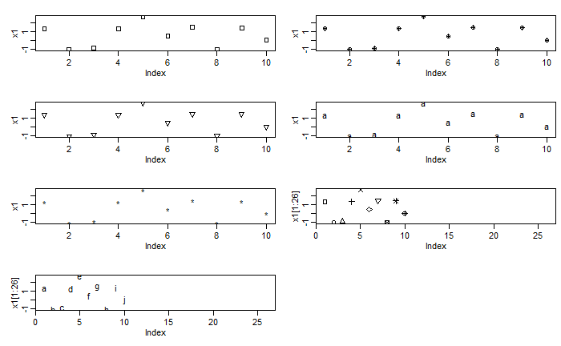

```r
plot(x1[1:26], type = "p", pch = letters)
```

## 2.9. Lines

**Line types in R : lty:**

`lty` for changing the lines type and `lwd` to change line width. The argument is a string (“blank”, “solid”, “dashed”, “dotted”, “dotdash”, “longdash”, or “twodash”) or an integer (0=blank, 1=solid (default), 2=dashed, 3=dotted, 4=dotdash, 5=longdash, 6=twodash)

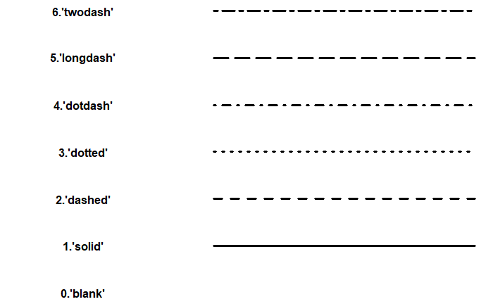

```r
#Line types
#++++++++++++++++++++++++++++++++++++++++++++
generateRLineTypes<-function(){
  oldPar<-par()
  par(font=2, mar=c(0,0,0,0))
  plot(1, pch="", ylim=c(0,6), xlim=c(0,0.7),  axes=FALSE,xlab="", ylab="")
  for(i in 0:6) lines(c(0.3,0.7), c(i,i), lty=i, lwd=3)
  text(rep(0.1,6), 0:6, labels=c("0.'blank'", "1.'solid'", "2.'dashed'", "3.'dotted'",
                                 "4.'dotdash'", "5.'longdash'", "6.'twodash'"))
  par(mar=oldPar$mar,font=oldPar$font )
}
generateRLineTypes()
```

Example:

```r
par(mfrow=c(3,3), mar=c(3,3,1,0)+.5, mgp=c(1.6,.6,0))  # set up the graphics
x1<-1:5
plot(x1, type = "l", lty = "blank")
plot(x1, type = "l", lty = "solid")
```

```r
plot(x1, type = "l", lty = "dashed")
plot(x1, type = "l", lty = "dotted")
```

```r
plot(x1, type = "l", lty = "dotdash")
plot(x1, type = "l", lty = "longdash")
```

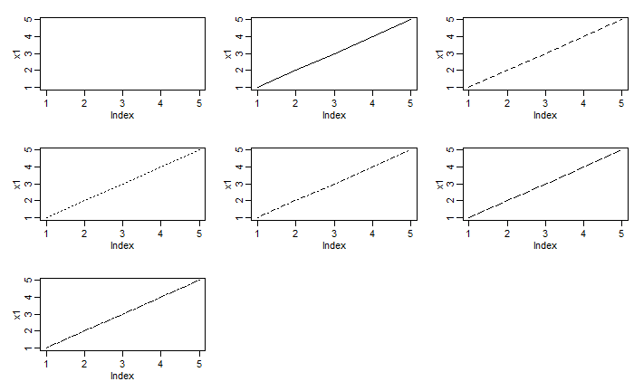

```r
plot(x1, type = "l", lty = "twodash")
```

**An additional `lines()` on a graph:**

Example:

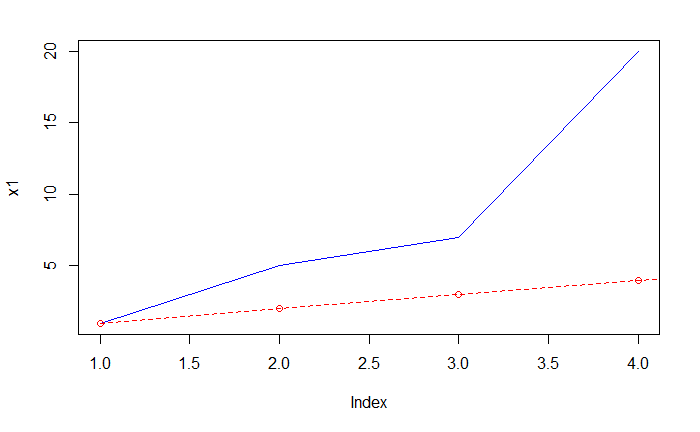

```r
x1<-c(1,5,7,20)
x2<-1:10
plot(x1, type = "l", lty = "solid",col="blue")
lines(x2, type = "o", lty = "dashed", col = "red")
```

**Straight abline():**

`abline()` can be used to add vertical, horizontal or regression lines.

Formula:

> abline(a=NULL, b=NULL, h=NULL, v=NULL, …)

Vertical line:

```r
par(mfrow=c(1,3), mar=c(3,3,1,0)+.5, mgp=c(1.6,.6,0))  # set up the graphics
#Example-1: Add one line
plot(cars)
abline(v=10, col="red")
```

```r
#Example-2: add 2 lines
# change line colors, sizes and types
plot(cars)
abline(v=c(5,15), col=c("blue", "blue"), lty=c(1,2), lwd=c(1, 3))
```

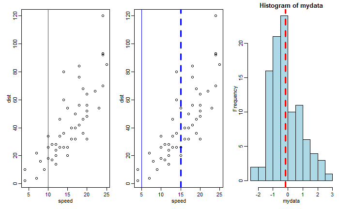

```r
#Example-3:
set.seed(1234); mydata<-rnorm(100)
hist(mydata, col="lightblue")
abline(v = mean(mydata), col="red", lwd=3, lty=2)
```

Horizontal line:

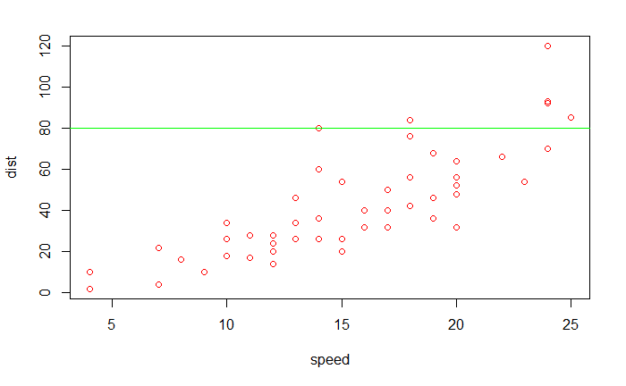

```r
plot(cars,col="red")
abline(h=80, col="green")
```

Regression line:

lm() function to fit linear model

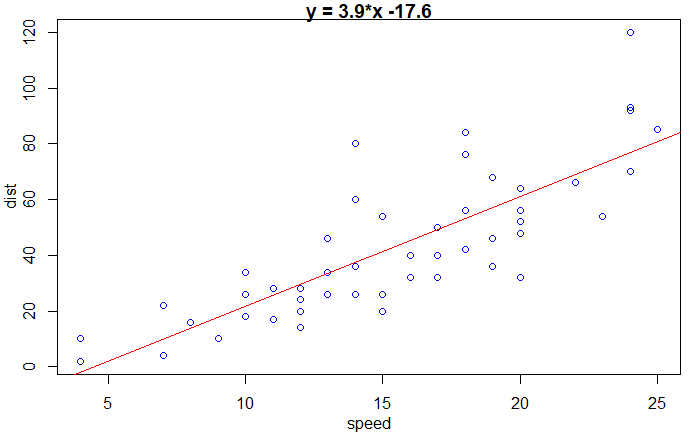

```r
par(mgp=c(2,1,0), mar=c(3,3,1,1))
# Fit regression line
require(stats)
reg<-lm(dist ~ speed, data = cars)
coeff=coefficients(reg)
# equation of the line :
eq = paste0("y = ", round(coeff[2],1), "*x ", round(coeff[1],1))
# plot
plot(cars, main=eq,col="blue")
abline(reg, col="red")
```